# Pied Flycatcher 2: Random Slopes

Simon Bonner

2021-11-22

This vignette continues the example of the pied flycatchers discussed in the vignette “pied-flycatchers-1” by adding a random slope to the fixed effects model. I highly recommend that you work through the other vignette first.

# Library

First you have to load the package:

```r
## Load package
library(dalmatian)
```

# Raw data

The raw data for this example is provided in the package and can be accessed with:

```r
## Load pied flycatcher data
data(pied_flycatchers_1)
```

```r
## Create variables bounding the true load
pfdata$lower=ifelse(pfdata$load==0,log(.001),log(pfdata$load-.049))
pfdata$upper=log(pfdata$load+.05)
```

# Model

The model we consider will be the similar to the random effects model in “pied-flycatchers-1”. We will modify this model by including a random, individual slope for the effect of $log(IVI)$ as well as the random intercept in the mean model. The new model for the mean will be:
$$\mu_{ij}=\beta_0 + \beta_1 \mathrm{log(IVI)_{ij}} + \beta_2 \mathrm{broodsize}_i + \beta_3 \mathrm{sex}_i + \epsilon_{1i} + \epsilon_{2i} \mathrm{log(IVI)_{ij}}$$
For convenience, we will also simplify the model of the dispersion by assuming that the variance is constant across all observations. This can be done by setting:
$$\log(\phi_{ij})=\psi_0$$
.

The objects defining the new mean and dispersion components are specified as:

```r
# Random component of mean
mymean=list(fixed=list(name="alpha",
                       formula=~ log(IVI) + broodsize + sex,
                       priors=list(c("dnorm",0,.001))),
            random=list(name="epsilon",
                        formula=~-1 + indidx + indidx:log(IVI)))


# Random component of dispersion
mydisp=list(fixed=list(name="psi",
                       formula=~1,
                       priors=list(c("dnorm",0,.001))),
            link="log")
```

## Running the Model with dalmatian

```r
## Set working directory
## By default uses a system temp directory. You probably want to change this.
workingDir <- tempdir()

## Define list of arguments for jags.model()
jm.args <- list(file=file.path(workingDir,"pied_flycatcher_3_jags.R"),n.adapt=1000)

## Define list of arguments for coda.samples()
cs.args <- list(n.iter=1000)

## Run the model using dalmatian
pfmcmc3 <- dalmatian(df=pfdata,
                     mean.model=mymean,
                     dispersion.model=mydisp,
                     jags.model.args=jm.args,
                     coda.samples.args=cs.args,
                     rounding=TRUE,
                     lower="lower",
                     upper="upper",
                     debug=FALSE)
```

## Results

Once again, we can use the wrapper functions provided with `dalmatian` to conduct convergence diagnostics and compute summary statistics for the posterior distribution from which we can make inference. Note that the chains have been thinned prior to creating the traceplots in order to reduce the size of the package.

1. Convergence diagnostics

```r
## Compute convergence diagnostics
pfconvergence3 <- convergence(pfmcmc3,raftery=list(r=.01))
```

```r
## Gelman-Rubin diagnostics
pfconvergence3$gelman
```

```
## Potential scale reduction factors:
##
##                            Point est. Upper C.I.
## alpha.(Intercept)                1.00       1.01
## alpha.log(IVI)                   1.00       1.01
## alpha.broodsizeIncreased         1.01       1.02
## alpha.sexMale                    1.02       1.06
## psi.(Intercept)                  1.00       1.01
## sd.epsilon.indidx                1.01       1.04
## sd.epsilon.indidx:log(IVI)       1.01       1.03
```

```r
## Raftery diagnostics
pfconvergence3$raftery
```

[output not shown]

```r
## Effective sample size
pfconvergence3$effectiveSize
```

```
##          alpha.(Intercept)             alpha.log(IVI)
##                   359.1056                  1548.6355
##   alpha.broodsizeIncreased              alpha.sexMale
##                   172.0363                   143.7425
##            psi.(Intercept)          sd.epsilon.indidx
##                   538.2383                   447.4075
## sd.epsilon.indidx:log(IVI)
##                   122.9022
```

2. Traceplots

```r
## Generate traceplots
pftraceplots3 <- traceplots(pfmcmc3, nthin = 20, show = FALSE)
```

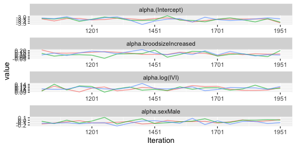

```r
## Fixed effects for mean
pftraceplots3$meanFixed
```

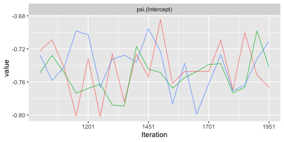

```r
## Fixed effects for dispersion
pftraceplots3$dispersionFixed
```

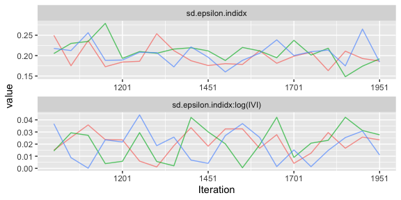

```r
## Random effects variances for mean
pftraceplots3$meanRandom
```

```r
## Random effects variances for dispersion
pftraceplots3$dispersionRandom
```

3. Numerical summaries

```r
## Compute numerical summaries
pfsummary3 <- summary(pfmcmc3)
```

```r
## Print numerical summaries
pfsummary3
```

```
##
## Iterations = 1001:2000
## Thinning interval = 1
## Number of chains = 3
## Sample size per chain = 1000
##
## Posterior Summary Statistics for Each Model Component
##
## Mean Model: Fixed Effects
##                     Mean Median   SD Lower 95% Lower 50% Upper 50% Upper 95%
## (Intercept)        -3.11  -3.10 0.09     -3.28     -3.17     -3.05     -2.93
## log(IVI)            0.11   0.12 0.01      0.09      0.11      0.13      0.14
## broodsizeIncreased  0.10   0.10 0.07     -0.02      0.04      0.13      0.24
## sexMale            -0.08  -0.08 0.07     -0.21     -0.13     -0.04      0.05
##
## Mean Model: Random Effects
##                 Mean Median   SD Lower 95% Lower 50% Upper 50% Upper 95%
## indidx          0.21   0.21 0.03      0.14      0.18      0.23      0.27
## indidx:log(IVI) 0.02   0.02 0.01      0.00      0.01      0.03      0.04
##
## Dispersion Model: Fixed Effects
##              Mean Median   SD Lower 95% Lower 50% Upper 50% Upper 95%
## (Intercept) -0.75  -0.75 0.03      -0.8     -0.77     -0.73     -0.69
```

4. Graphical summaries

```r
## Generate caterpillar
pfcaterpillar3 <- caterpillar(pfmcmc3,show = FALSE)
```

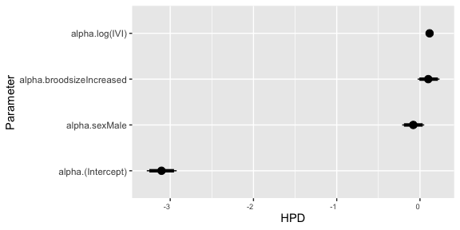

```r
## Fixed effects for mean
pfcaterpillar3$meanFixed
```

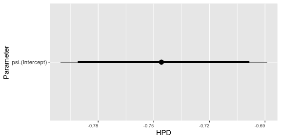

```r
## Fixed effects for dispersion
pfcaterpillar3$dispersionFixed
```

The convergence diagnostics and traceplots suggest that the chains should be run for longer. In particular, the effective sample size for the variance of the random slopes is very small, but we will proceed with inference for illustration. In the numerical summaries we see that the estimated variance of the random slopes is very small, 0.0204748 with 95% credible interval (2.7611746^{-5},0.040385). This suggests that there is very little inter-individual variation in the effect of `log(IVI)`.

Estimates of the individual random effects (predictions for frequentists) can be obtained from the function `ranef()`. This function computes posterior summary statistics for the individual random effects. In this case, the random effects for the mean include both the intercept and the effect of `log(IVI)`.

The following code computes the summary statistics and plots the predicted values of the random slopes with HPD 95% confidence intervals.

```r
## Compute summary statistics for random effects
pfranef3 <- ranef(pfresults3)
```

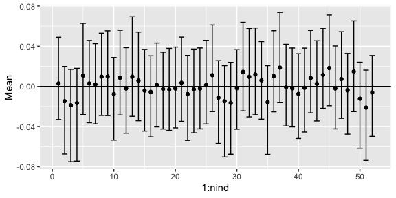

```r
## Load ggplot2
library(ggplot2)

## Identify number of individuals
nind <- nlevels(pfdata$indidx)

## Plot predicted random slopes
ggplot(data=as.data.frame(pfranef3$mean[nind+(1:nind),]),aes(x=1:nind,y=Mean)) +
  geom_point() +
  geom_errorbar(aes(ymin=`Lower 95%`,ymax=`Upper 95%`)) +
  geom_abline(intercept=0,slope=0)
```

Note that the 95% credible intervals for all of the values include 0. This is further evidence that the effect of `log(IVI)` does not vary significantly between the individuals.